# NFL 2020 Week 21

MAJ Daniel Baller

## Instructor Group Predictions

This Week's Predictions

Week 21

| Game | Prediction | Winner | Correct | Correct Votes | Correct Percent |
| --- | --- | --- | --- | --- | --- |
| 1 | Kansas City Chiefs | Tampa Bay Buccaneers | No | 7 | 0.4667 |

Our win percentage for the week is 0

Our season win percentage so far is 0.6642

Games picked this season 265

Correct Games this season 176

predictions this week

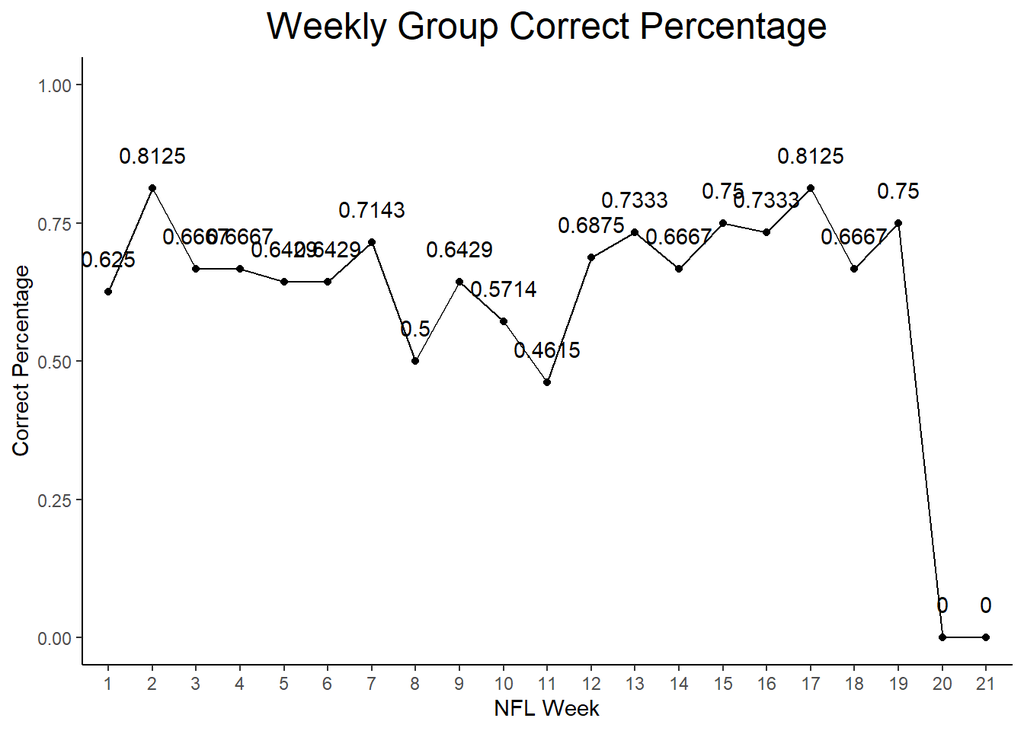

## Individual Predictions

Individual Results

Week 21

Name

Weekly # Correct

Percent

Weeks Picked

Season Percent

Adj Season Percent

Season Trend

Week 1

Week 2

Week 3

Week 4

Week 5

Week 6

Week 7

Week 8

Week 9

Week 10

Week 11

Week 12

Week 13

Week 14

Week 15

Week 16

Week 17

Week 18

Week 19

Week 20

Week 21

Kevin Cummiskey

13

11

9

9

10

7

9

5

10

9

7

12

10

10

12

10

14

4

3

2

1

1

21

0.6679

0.6679

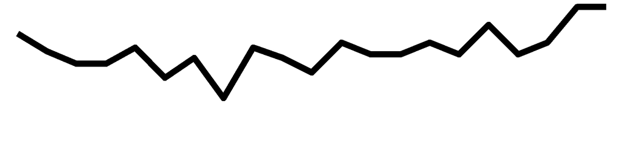

Gregory Minetos

9

14

10

12

8

8

12

7

10

7

7

11

9

9

12

8

13

4

3

1

1

1

21

0.6604

0.6604

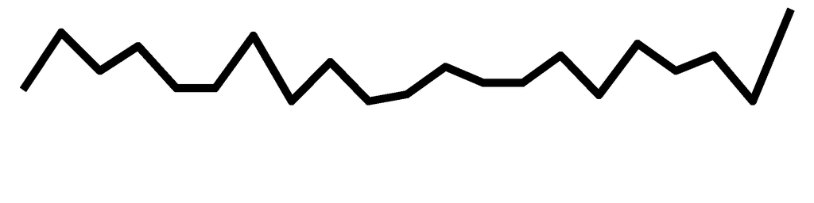

Michael Prokos

9

12

9

8

11

10

9

7

9

9

7

10

11

12

12

9

NA

4

4

1

1

1

20

0.6586

0.6272

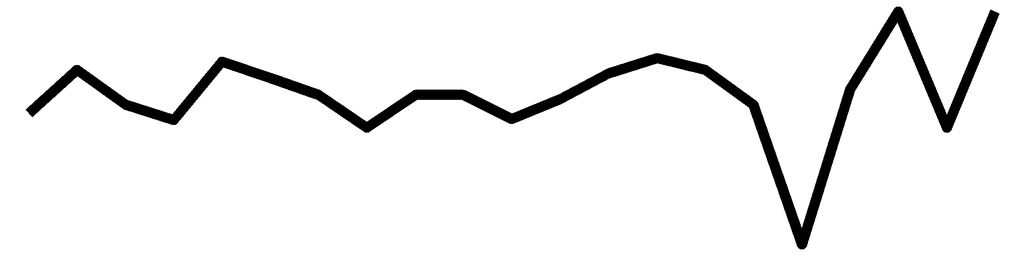

Margaret Wieczorek

11

14

9

9

8

NA

10

8

9

8

7

8

11

11

12

NA

NA

NA

NA

NA

1

1

15

0.6538

0.4670

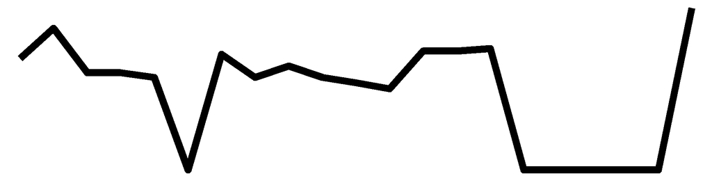

Gabriel Costa

9

12

6

9

10

7

9

7

10

10

9

NA

11

8

9

10

13

3

3

0

1

1

20

0.6265

0.5967

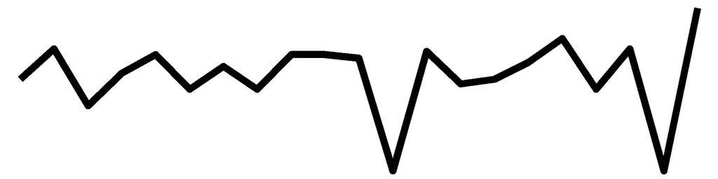

Nicholas Reisweber

9

10

10

8

10

7

8

8

10

9

6

14

9

8

9

11

NA

4

2

1

1

1

20

0.6185

0.5890

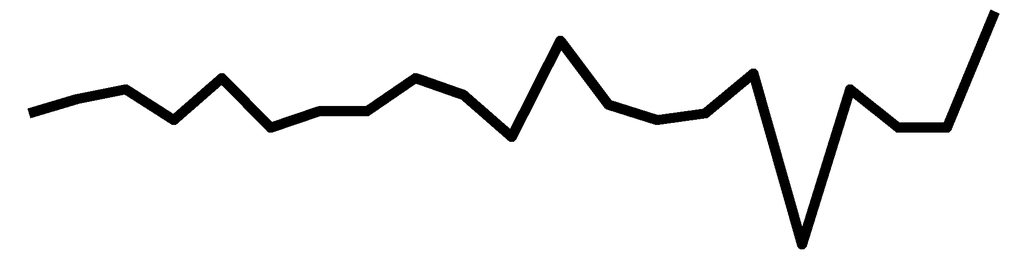

Eric Swenson

4

8

10

9

9

8

9

8

7

8

8

10

11

9

12

11

13

3

3

1

1

1

21

0.6113

0.6113

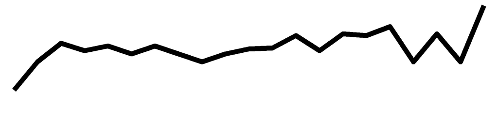

James Starling

15

12

9

12

10

NA

11

8

10

10

6

11

11

7

10

14

NA

5

2

1

0

0

19

0.6979

0.6314

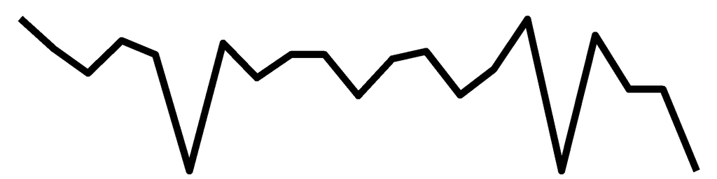

James Pleuss

9

12

10

12

7

8

10

9

9

10

7

10

12

12

11

9

NA

4

4

0

0

0

20

0.6627

0.6311

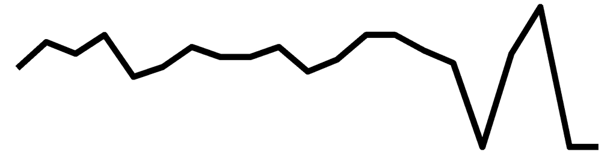

Josephine Cammack

9

11

12

10

9

9

11

7

6

8

NA

9

12

11

12

NA

12

3

NA

1

0

0

18

0.6524

0.5592

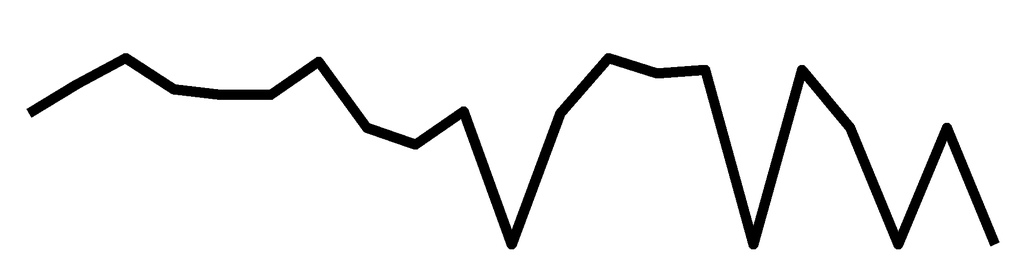

Shane Clark

10

14

9

9

9

9

10

NA

11

7

7

12

10

11

NA

NA

10

2

NA

0

0

0

17

0.6481

0.5247

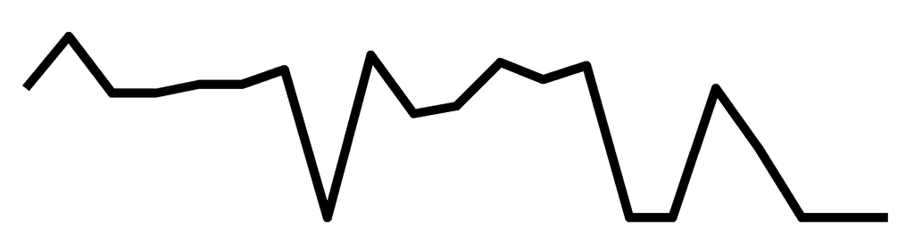

Daniel Baller

11

10

10

9

9

5

8

9

11

10

8

11

11

11

10

11

12

3

2

0

0

0

21

0.6453

0.6453

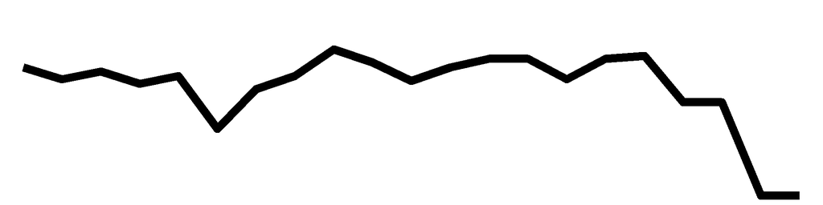

Frank Czerniakowski

7

13

10

9

8

6

9

6

11

5

9

11

9

12

NA

10

13

3

3

NA

0

0

19

0.6235

0.5641

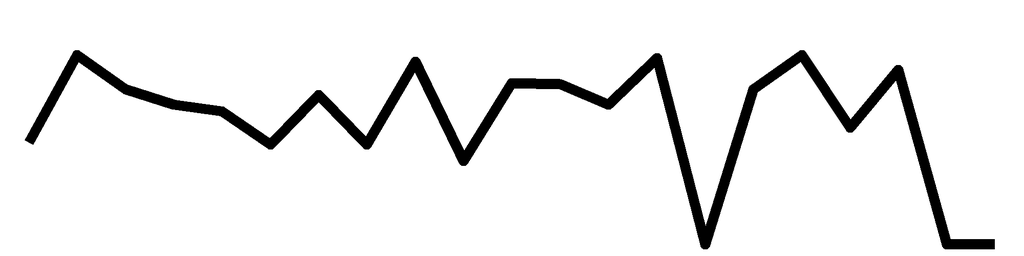

Blake Schwartz

10

9

10

10

10

9

9

6

5

8

7

9

11

10

11

11

13

3

3

1

0

0

21

0.6226

0.6226

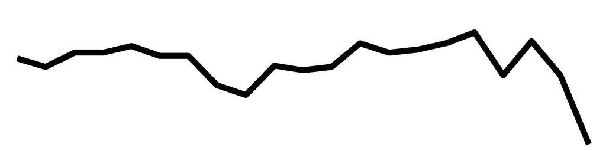

Tina Hartley

9

11

10

8

8

9

9

7

3

8

6

10

9

9

12

10

14

3

3

1

0

0

21

0.6000

0.6000

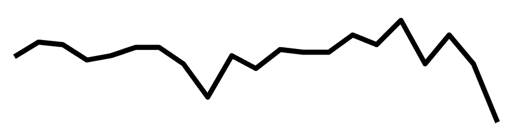

Daniel Richardson

13

11

10

10

8

NA

8

NA

NA

NA

NA

NA

NA

NA

NA

NA

NA

NA

NA

NA

NA

0

6

0.6667

0.1905

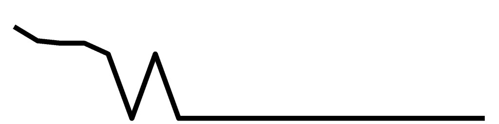

Travis Russell

11

8

8

11

10

10

10

8

NA

NA

7

NA

NA

NA

NA

NA

NA

NA

NA

NA

NA

0

9

0.6336

0.2715

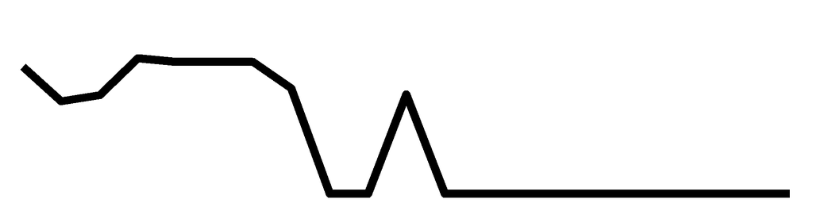

John Kearby

9

11

6

9

9

8

12

6

9

10

6

10

11

9

11

10

NA

5

3

NA

NA

0

18

0.6260

0.5366

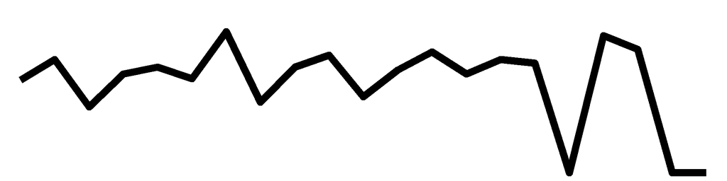

Welvin Lucero

9

11

9

10

NA

NA

11

8

NA

8

5

NA

NA

10

NA

NA

NA

NA

3

NA

NA

0

10

0.6176

0.2941

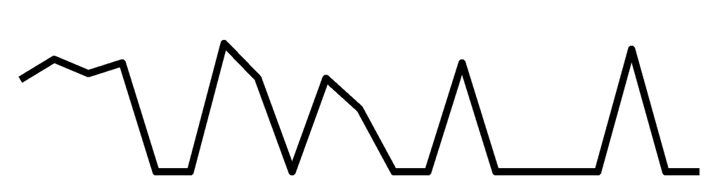

Kevin Quigley

8

8

9

10

10

8

8

6

8

7

9

10

NA

NA

11

9

NA

3

2

1

NA

0

17

0.5826

0.4716

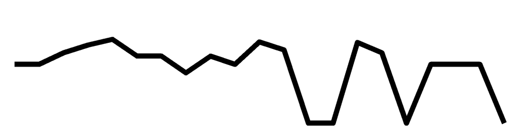

Andrew Lee

9

10

8

NA

NA

NA

NA

NA

NA

NA

NA

NA

NA

NA

NA

NA

NA

NA

NA

NA

NA

0

3

0.5745

0.0821

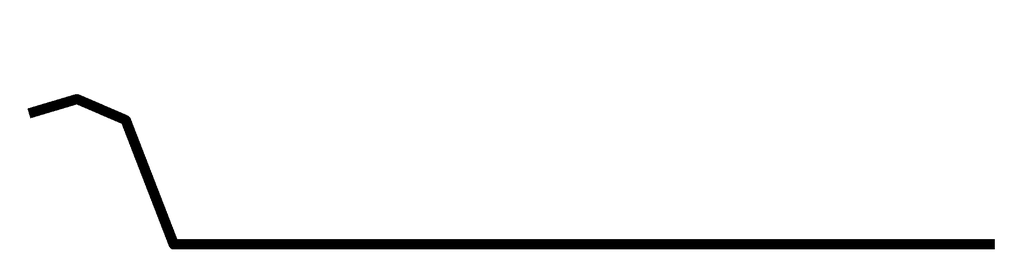

Timothy Moore

10

11

8

9

7

9

7

7

7

NA

NA

NA

9

10

8

NA

NA

4

NA

0

NA

0

14

0.5699

0.3799

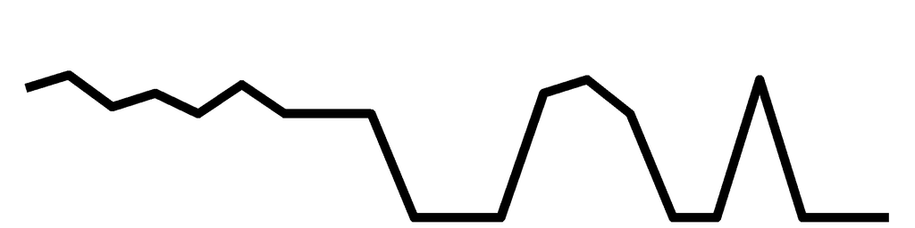

Congrats Kevin Cummiskey for having the best picks this week, with a correct percentage of 1, Congrats Gregory Minetos for having the best picks this week, with a correct percentage of 1, Congrats Michael Prokos for having the best picks this week, with a correct percentage of 1, Congrats Margaret Wieczorek for having the best picks this week, with a correct percentage of 1, Congrats Gabriel Costa for having the best picks this week, with a correct percentage of 1, Congrats Nicholas Reisweber for having the best picks this week, with a correct percentage of 1, Congrats Eric Swenson for having the best picks this week, with a correct percentage of 1

| Name | Week 1 | Week 2 | Week 3 | Week 4 | Week 5 | Week 6 | Week 7 | Week 8 | Week 9 | Week 10 | Week 11 | Week 12 | Week 13 | Week 14 | Week 15 | Week 16 | Week 17 | Week 18 | Week 19 | Week 20 | Week 21 | Percent | Weeks Picked | Season Percent | Adj Season Percent | Season Trend |
| --- | --- | --- | --- | --- | --- | --- | --- | --- | --- | --- | --- | --- | --- | --- | --- | --- | --- | --- | --- | --- | --- | --- | --- | --- | --- | --- |
| Kevin Cummiskey | 13 | 11 | 9 | 9 | 10 | 7 | 9 | 5 | 10 | 9 | 7 | 12 | 10 | 10 | 12 | 10 | 14 | 4 | 3 | 2 | 1 | 1 | 21 | 0.6679 | 0.6679 |  |
| Gregory Minetos | 9 | 14 | 10 | 12 | 8 | 8 | 12 | 7 | 10 | 7 | 7 | 11 | 9 | 9 | 12 | 8 | 13 | 4 | 3 | 1 | 1 | 1 | 21 | 0.6604 | 0.6604 |  |
| Michael Prokos | 9 | 12 | 9 | 8 | 11 | 10 | 9 | 7 | 9 | 9 | 7 | 10 | 11 | 12 | 12 | 9 | NA | 4 | 4 | 1 | 1 | 1 | 20 | 0.6586 | 0.6272 |  |
| Margaret Wieczorek | 11 | 14 | 9 | 9 | 8 | NA | 10 | 8 | 9 | 8 | 7 | 8 | 11 | 11 | 12 | NA | NA | NA | NA | NA | 1 | 1 | 15 | 0.6538 | 0.467 |  |
| Gabriel Costa | 9 | 12 | 6 | 9 | 10 | 7 | 9 | 7 | 10 | 10 | 9 | NA | 11 | 8 | 9 | 10 | 13 | 3 | 3 | 0 | 1 | 1 | 20 | 0.6265 | 0.5967 |  |
| Nicholas Reisweber | 9 | 10 | 10 | 8 | 10 | 7 | 8 | 8 | 10 | 9 | 6 | 14 | 9 | 8 | 9 | 11 | NA | 4 | 2 | 1 | 1 | 1 | 20 | 0.6185 | 0.589 |  |
| Eric Swenson | 4 | 8 | 10 | 9 | 9 | 8 | 9 | 8 | 7 | 8 | 8 | 10 | 11 | 9 | 12 | 11 | 13 | 3 | 3 | 1 | 1 | 1 | 21 | 0.6113 | 0.6113 |  |
| James Starling | 15 | 12 | 9 | 12 | 10 | NA | 11 | 8 | 10 | 10 | 6 | 11 | 11 | 7 | 10 | 14 | NA | 5 | 2 | 1 | 0 | 0 | 19 | 0.6979 | 0.6314 |  |
| James Pleuss | 9 | 12 | 10 | 12 | 7 | 8 | 10 | 9 | 9 | 10 | 7 | 10 | 12 | 12 | 11 | 9 | NA | 4 | 4 | 0 | 0 | 0 | 20 | 0.6627 | 0.6311 |  |
| Josephine Cammack | 9 | 11 | 12 | 10 | 9 | 9 | 11 | 7 | 6 | 8 | NA | 9 | 12 | 11 | 12 | NA | 12 | 3 | NA | 1 | 0 | 0 | 18 | 0.6524 | 0.5592 |  |
| Shane Clark | 10 | 14 | 9 | 9 | 9 | 9 | 10 | NA | 11 | 7 | 7 | 12 | 10 | 11 | NA | NA | 10 | 2 | NA | 0 | 0 | 0 | 17 | 0.6481 | 0.5247 |  |
| Daniel Baller | 11 | 10 | 10 | 9 | 9 | 5 | 8 | 9 | 11 | 10 | 8 | 11 | 11 | 11 | 10 | 11 | 12 | 3 | 2 | 0 | 0 | 0 | 21 | 0.6453 | 0.6453 |  |
| Frank Czerniakowski | 7 | 13 | 10 | 9 | 8 | 6 | 9 | 6 | 11 | 5 | 9 | 11 | 9 | 12 | NA | 10 | 13 | 3 | 3 | NA | 0 | 0 | 19 | 0.6235 | 0.5641 |  |
| Blake Schwartz | 10 | 9 | 10 | 10 | 10 | 9 | 9 | 6 | 5 | 8 | 7 | 9 | 11 | 10 | 11 | 11 | 13 | 3 | 3 | 1 | 0 | 0 | 21 | 0.6226 | 0.6226 |  |
| Tina Hartley | 9 | 11 | 10 | 8 | 8 | 9 | 9 | 7 | 3 | 8 | 6 | 10 | 9 | 9 | 12 | 10 | 14 | 3 | 3 | 1 | 0 | 0 | 21 | 0.6 | 0.6 |  |
| Daniel Richardson | 13 | 11 | 10 | 10 | 8 | NA | 8 | NA | NA | NA | NA | NA | NA | NA | NA | NA | NA | NA | NA | NA | NA | 0 | 6 | 0.6667 | 0.1905 |  |
| Travis Russell | 11 | 8 | 8 | 11 | 10 | 10 | 10 | 8 | NA | NA | 7 | NA | NA | NA | NA | NA | NA | NA | NA | NA | NA | 0 | 9 | 0.6336 | 0.2715 |  |
| John Kearby | 9 | 11 | 6 | 9 | 9 | 8 | 12 | 6 | 9 | 10 | 6 | 10 | 11 | 9 | 11 | 10 | NA | 5 | 3 | NA | NA | 0 | 18 | 0.626 | 0.5366 |  |
| Welvin Lucero | 9 | 11 | 9 | 10 | NA | NA | 11 | 8 | NA | 8 | 5 | NA | NA | 10 | NA | NA | NA | NA | 3 | NA | NA | 0 | 10 | 0.6176 | 0.2941 |  |
| Kevin Quigley | 8 | 8 | 9 | 10 | 10 | 8 | 8 | 6 | 8 | 7 | 9 | 10 | NA | NA | 11 | 9 | NA | 3 | 2 | 1 | NA | 0 | 17 | 0.5826 | 0.4716 |  |
| Andrew Lee | 9 | 10 | 8 | NA | NA | NA | NA | NA | NA | NA | NA | NA | NA | NA | NA | NA | NA | NA | NA | NA | NA | 0 | 3 | 0.5745 | 0.0821 |  |
| Timothy Moore | 10 | 11 | 8 | 9 | 7 | 9 | 7 | 7 | 7 | NA | NA | NA | 9 | 10 | 8 | NA | NA | 4 | NA | 0 | NA | 0 | 14 | 0.5699 | 0.3799 |  |

[figure not shown]

## MA206 Group Predictions

This Week's MA206 Predictions

Week 21

| Game | Prediction | Winner | Correct | Correct Votes | Correct Percent |
| --- | --- | --- | --- | --- | --- |
| 1 | Tampa Bay Buccaneers | Tampa Bay Buccaneers | Yes | 4 | 0.5714 |

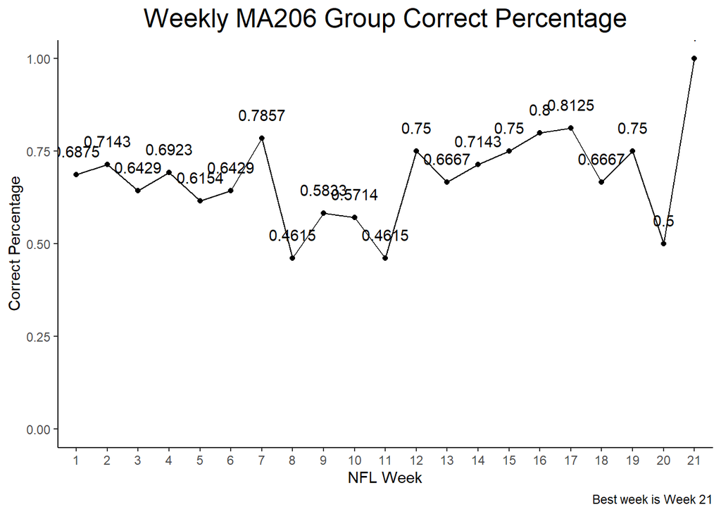